# Capstone EDA

# The Data

```r
library(tidyverse)
library(caret)
library(DMwR2)
library(e1071)
library(ipred)
library(xgboost)
library(kableExtra)
library(ggthemes)
library(egg)
library(forcats)
library(summarytools)
library(forecast)
library(doParallel)
```

Reading in the data,

```r
df <- read.csv("movies_clean_v4.csv")
kable(head(df,1)) |> kable_styling()
```

| title | year | rated | released | runtime | genre | director | writer | actors | plot | language | country | awards | poster | ratings | metascore | imdbrating | imdbvotes | imdbid | type | dvd | boxoffice | production | website | response | directorid | actorid | budget | num_directors | num_actors | … |
| --- | --- | --- | --- | --- | --- | --- | --- | --- | --- | --- | --- | --- | --- | --- | --- | --- | --- | --- | --- | --- | --- | --- | --- | --- | --- | --- | --- | --- | --- | --- |
| Spider-Man | 2002 | PG-13 | 2002-05-03 | 121 | Action | Sam Raimi | Stan Lee, Steve Ditko, David Koepp | Tobey Maguire, Kirsten Dunst, Willem Dafoe | After being bitten by a genetically-modified spider, a shy teenager gains spider-like abilities that he uses to fight injustice as a masked superhero and face a vengeful enemy. | English | United States | Nominated for 2 Oscars. 17 wins & 63 nominations total | https://m.media-amazon.com/images/M/MV5BZDEyN2NhMjgtMjdhNi00MmNlLWE5YTgtZGE4MzNjMTRlMGEwXkEyXkFqcGdeQXVyNDUyOTg3Njg@._V1_SX300.jpg | {‘Source’: ‘Internet Movie Database’, ‘Value’: ‘7.4/10’} | 73 | 7.4 | 852,452 | tt0145487 | movie | 25 Apr 2013 | 407022860 |  | NA | True | [‘nm0000600’] | [‘nm0001497’, ‘nm0000379’, ‘nm0000353’] | 1.39e+08 | 1 | 3 | … |

First we’ll subset the desired columns,

```r
colnames(df)
```

```
##  [1] "title"            "year"             "rated"            "released"
##  [5] "runtime"          "genre"            "director"         "writer"
##  [9] "actors"           "plot"             "language"         "country"
## [13] "awards"           "poster"           "ratings"          "metascore"
## [17] "imdbrating"       "imdbvotes"        "imdbid"           "type"
## [21] "dvd"              "boxoffice"        "production"       "website"
## [25] "response"         "directorid"       "actorid"          "budget"
## [29] "num_directors"    "num_actors"       "actor_rev5"       "actor_rev10"
## [33] "director_films5"  "actor_films5"     "actor_films10"    "director_rev10"
## [37] "director_films10" "director_rev5"
```

```r
cols <- c("year","rated","released","runtime","genre","language","country","boxoffice","budget","num_directors","num_actors","actor_films5","actor_films10","actor_rev5","actor_rev10","director_films5","director_films10","director_rev5","director_rev10")

df <- df |>
  select(all_of(cols))

kable(head(df)) |> kable_styling()
```

| year | rated | released | runtime | genre | language | country | boxoffice | budget | num_directors | num_actors | actor_films5 | actor_films10 | actor_rev5 | actor_rev10 | director_films5 | director_films10 | director_rev5 | director_rev10 |
| --- | --- | --- | --- | --- | --- | --- | --- | --- | --- | --- | --- | --- | --- | --- | --- | --- | --- | --- |
| 2002 | PG-13 | 2002-05-03 | 121 | Action | English | United States | 407022860 | 1.39e+08 | 1 | 3 | 0 | 0 | 0 | 0 | 0 | 0 | 0 | 0 |
| 2002 | PG | 2002-05-16 | 142 | Action | English | United States | 310676740 | 1.15e+08 | 1 | 3 | 1 | 1 | 108638745 | 108638745 | 0 | 0 | 0 | 0 |
| 2002 | PG | 2002-11-15 | 161 | Adventure | English, Latin | United Kingdom, United States | 262641637 | 1.00e+08 | 1 | 3 | 0 | 0 | 0 | 0 | 0 | 0 | 0 | 0 |
| 2002 | PG-13 | 2002-08-02 | 106 | Drama | English, Portuguese | United States | 227966634 | 7.20e+07 | 1 | 3 | 1 | 1 | 78122718 | 78122718 | 0 | 0 | 0 | 0 |
| 2002 | PG | 2002-08-02 | 95 | Comedy | English, Greek | Canada, United States | 241438208 | 5.00e+06 | 1 | 3 | 0 | 0 | 0 | 0 | 0 | 0 | 0 | 0 |
| 2002 | PG-13 | 2002-12-18 | 179 | Action | English, Sindarin, Old English | New Zealand, United States | 342952511 | 9.40e+07 | 1 | 3 | 0 | 0 | 0 | 0 | 0 | 0 | 0 | 0 |

The following columns will be converted to factors:

`rated` - contains the film’s ratings.  
`genre` - contains the film’s genre. `num_actors` - the number of leading actors per Imdb.  
`num_directors` - the number of directors per Imdb.

The following column will be converted to date:

`released` - contains the film’s release date

```r
df <- df |>
  mutate(rated = as.factor(rated),
         genre = as.factor(genre),
         num_actors = as.factor(num_actors),
         num_directors = as.factor(num_directors),
         released = as.Date(released))
```

Extracting the month from release date,

```r
df <- df |>
  mutate(month = as.factor(months(released)))
```

Let’s see how many unique values there are in the `language` and `country` columnns,

First, language:

```r
n_distinct(df$language)
```

```
## [1] 688
```

We take a look at the unique languages and notice that there are some languages that contain ““, and some that contain”None”. First we convert the empty strings to “None”, then we update the `variable` column: if a film contains the language English, we label it “English”, if the film contains the language “None”, we leave it as “None”, otherwise, we label it “Foreign”.

```r
# replace empty strings with "None"
df$language <- ifelse(df$language == "", "None", df$language)

# convert language values to "English", "Foreign", or "None"
df$language <- as.factor(ifelse(grepl("English", df$language),
                                "English",
                                ifelse(df$language == "None",
                                       "None","Foreign")))

kable(sort(table(df$language), decreasing=TRUE), col.names=NULL) |>
  kable_styling()
```

| English | 3490 |
| --- | --- |
| Foreign | 157 |
| None | 10 |

Now we take a look at country.

```r
n_distinct(df$country)
```

```
## [1] 618
```

One of the issues here, like with the `language` column, is that there is no hierarchy given - countries are listed in alphabetical order. As such, we’ll assume that if the United States is listed, the film can be considered domestic, whereas if United States is not listed, it will be considered foreign. We also observe that there are some missing observations that contain empty strings. We’ll fill those as “None”.

```r
# fill empty rows
df$country <- ifelse(df$country == "", "None", df$country)

# recode the country variable
df$country <- as.factor(ifelse(grepl("United States", df$country),
                               "United States",
                               ifelse(df$country == "None",
                                      "None","Foreign")))

kable(sort(table(df$country), decreasing=TRUE), col.names=NULL) |>
  kable_styling()
```

| United States | 3307 |
| --- | --- |
| Foreign | 346 |
| None | 4 |

Lastly, we examine our columns stored as double precision. We observe that the actor and director revenue columns contain some floats, so we leave those alone. We change the datatype for the `budget` column from double precision to integer.

```r
df$budget <- as.integer(df$budget)
```

The data we are interested in is from 2012 on. We collected data beginning in 2002 in order to calculate the actor and director earnings for the previous 5- to 10- years. So now we subset the dataframe to only records from 2012 on and drop the year and released column altogether.

```r
df <- df |>
  filter(year >= 2012) |>
  select(-c(year,released))
```

# Exploratory Data Analysis

We now have a dataframe consisting of 1859 observations and 18 variables. Let’s take a look first at our missing values.

```r
colnames(df)[colSums(is.na(df)) > 0]
```

```
## [1] "budget"
```

Only budget contains NAs,

```r
colMeans(is.na(df)) %>% .[. > 0]
```

```
##    budget
## 0.2383002
```

About 24% of the films are missing budget numbers. However, this missingness might prove informative:

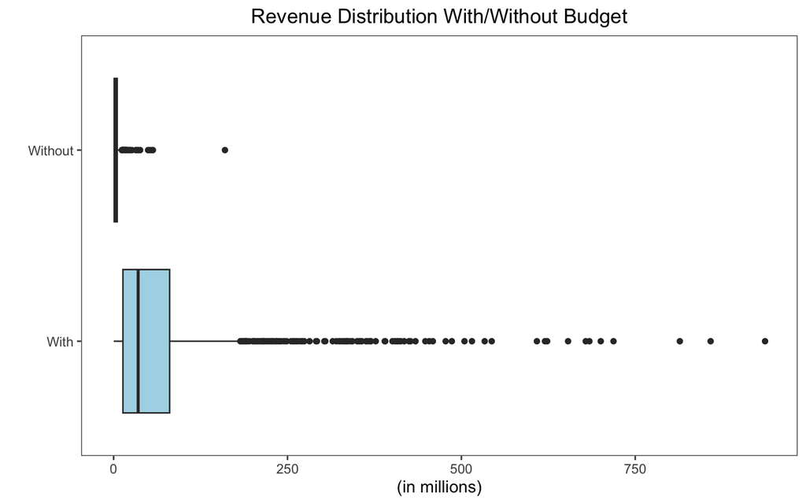

```r
ggplot(df, aes(y = ifelse(is.na(budget), "Without", "With"), x = boxoffice*0.000001)) +
  geom_boxplot(fill = "lightblue") +
  labs(x = "(in millions)",
       y = "",
       title = "Revenue Distribution With/Without Budget") +
  theme_few() +
  theme(plot.title = element_text(hjust = 0.5))
```

We can see that the films that do not have budget data demonstrate noticeably lower revenue which is out outcome variable, so we will keep the NAs for our model.

Let’s view the summary statistics for the dataset,

```r
summary(df)
```

```
##        rated        runtime            genre        language
##  R        :738   Min.   : 39.0   Action   :519   English:1732
##  PG-13    :695   1st Qu.: 97.0   Comedy   :352   Foreign: 118
##  PG       :271   Median :108.0   Drama    :295   None   :   9
##  Not Rated: 74   Mean   :111.3   Biography:173
##           : 41   3rd Qu.:122.0   Animation:155
##  G        : 18   Max.   :195.0   Adventure: 91
##  (Other)  : 22                   (Other)  :274
##           country       boxoffice             budget          num_directors
##  Foreign      : 236   Min.   :   159014   Min.   :   100000   1:1667
##  None         :   4   1st Qu.:  4941632   1st Qu.: 12000000   2: 167
##  United States:1619   Median : 20777061   Median : 30000000   3:  25
##                       Mean   : 54189923   Mean   : 52157266
##                       3rd Qu.: 60093010   3rd Qu.: 68000000
##                       Max.   :936662225   Max.   :356000000
##                                           NA's   :443
##  num_actors  actor_films5    actor_films10     actor_rev5
##  0:   6     Min.   : 0.000   Min.   : 0.00   Min.   :0.000e+00
##  1:   6     1st Qu.: 1.000   1st Qu.: 2.00   1st Qu.:1.104e+07
##  2:   1     Median : 4.000   Median : 8.00   Median :2.138e+08
##  3:1846     Mean   : 5.455   Mean   :10.09   Mean   :4.326e+08
##             3rd Qu.: 9.000   3rd Qu.:16.00   3rd Qu.:6.438e+08
##             Max.   :27.000   Max.   :44.00   Max.   :4.470e+09
##
##   actor_rev10        director_films5 director_films10 director_rev5
##  Min.   :0.000e+00   Min.   :0.000   Min.   : 0.00    Min.   :0.000e+00
##  1st Qu.:4.814e+07   1st Qu.:0.000   1st Qu.: 0.00    1st Qu.:0.000e+00
##  Median :4.503e+08   Median :0.000   Median : 1.00    Median :0.000e+00
##  Mean   :7.592e+08   Mean   :0.759   Mean   : 1.53    Mean   :6.138e+07
##  3rd Qu.:1.168e+09   3rd Qu.:1.000   3rd Qu.: 2.00    3rd Qu.:6.549e+07
##  Max.   :7.316e+09   Max.   :9.000   Max.   :14.00    Max.   :2.174e+09
##
##  director_rev10            month
##  Min.   :0.000e+00   August   :185
##  1st Qu.:0.000e+00   October  :182
##  Median :1.273e+07   November :172
##  Mean   :1.244e+08   September:163
##  3rd Qu.:1.504e+08   December :158
##  Max.   :2.693e+09   February :155
##                      (Other)  :844
```

Looking at only the numeric variables,

```r
descr(df,
      stats = c("min","q1","med","mean","q3","sd","max"),
      round.digits = 2,
      transpose = TRUE,
      headings = FALSE,
      style = "rmarkdown") |>
  kable(format = "html", digits = 2) |>
  kable_styling(full_width = FALSE) |>
  scroll_box(height = "200px", width = "100%")
```

|  | Min | Q1 | Median | Mean | Q3 | Std.Dev | Max |
| --- | --- | --- | --- | --- | --- | --- | --- |
| actor_films10 | 0 | 2 | 8 | 10.09 | 16 | 9.28 | 44 |
| actor_films5 | 0 | 1 | 4 | 5.45 | 9 | 5.16 | 27 |
| actor_rev10 | 0 | 48091713 | 450255348 | 759167254.42 | 1168551880 | 897987469.29 | 7316416397 |
| actor_rev5 | 0 | 10726630 | 213778031 | 432617771.15 | 644587426 | 571830292.26 | 4469634688 |
| boxoffice | 159014 | 4936819 | 20777061 | 54189922.78 | 60311495 | 92859139.66 | 936662225 |
| budget | 100000 | 12000000 | 30000000 | 52157266.12 | 68000000 | 58391659.06 | 356000000 |
| director_films10 | 0 | 0 | 1 | 1.53 | 2 | 1.99 | 14 |
| director_films5 | 0 | 0 | 0 | 0.76 | 1 | 1.07 | 9 |
| director_rev10 | 0 | 0 | 12727256 | 124370528.27 | 150394119 | 230007052.55 | 2693332806 |
| director_rev5 | 0 | 0 | 0 | 61377871.21 | 65565279 | 135630420.74 | 2173799662 |
| runtime | 39 | 97 | 108 | 111.27 | 122 | 19.84 | 195 |

We can see that there is a wide range of values across the numeric variables. We see there is a film category that contains an empty string, so we convert those to “None”.

```r
# replace empty strings with "None"
df$rated <- fct_recode(df$rated, "None" = "", .default = "Other")
kable(sort(prop.table(table(df$rated)), decreasing=TRUE), col.names=NULL) |>
  kable_styling()
```

| R | 0.3969876 |
| --- | --- |
| PG-13 | 0.3738569 |
| PG | 0.1457773 |
| Not Rated | 0.0398063 |
| None | 0.0220549 |
| G | 0.0096826 |
| TV-MA | 0.0032275 |
| Unrated | 0.0032275 |
| TV-14 | 0.0026896 |
| TV-PG | 0.0021517 |
| 16+ | 0.0005379 |
| NC-17 | 0.0000000 |

```r
df |>
  select(rated) |>
  mutate(rated = ifelse(rated %in% c("R","PG","PG-13"), "R/PG/PG-13", "Other")) |>
  table() |>
  prop.table() |>
  sort(decreasing = TRUE) |>
  kable(col.names=NULL) |>
  kable_styling()
```

| R/PG/PG-13 | 0.9166218 |
| --- | --- |
| Other | 0.0833782 |

Nearly 80% of all films in our dataset are rated R or PG-13.

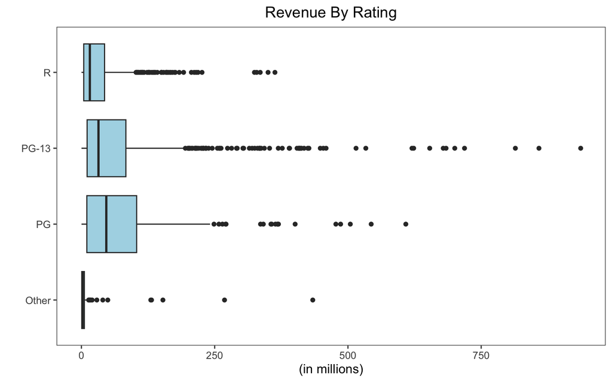

```r
df |>
  select(rated, boxoffice) |>
  mutate(rated = as.character(rated)) |>
  mutate(rated = ifelse(rated %in% c("R","PG","PG-13"), rated, "Other")) |>
  ggplot(aes(x = boxoffice*0.000001, y = rated)) +
  geom_boxplot(fill = "lightblue") +
  labs(x = "(in millions)",
       y = "",
       title = "Revenue By Rating") +
  theme_few() +
  theme(plot.title = element_text(hjust = 0.5))
```

```r
df |>
  select(rated, boxoffice) |>
  mutate(rated = as.character(rated)) |>
  mutate(rated = ifelse(rated %in% c("R","PG","PG-13"), rated, "Other")) |>
  group_by(rated) |>
  summarise(median = median(boxoffice)) |>
  arrange(desc(median)) |>
  kable() |>
  kable_styling()
```

| rated | median |
| --- | --- |
| PG | 46700633 |
| PG-13 | 32015231 |
| R | 15841514 |
| Other | 2553002 |

For the purpose of this study, given that we are examining a film’s performance represented as a function of domestic box office, we restrict our dataset to films that contain valid ratings.

```r
df <- df |>
  filter(rated %in% c("G","NC-17","PG","PG-13","R")) |>
  mutate(rated = droplevels(rated))
```

```r
kable(sort(round(prop.table(table(df$language)),3), decreasing=TRUE), col.names=NULL) |>
  kable_styling()
```

| English | 0.974 |
| --- | --- |
| Foreign | 0.025 |
| None | 0.001 |

```r
kable(sort(round(prop.table(table(df$country)),3), decreasing=TRUE), col.names=NULL) |>
  kable_styling()
```

| United States | 0.924 |
| --- | --- |
| Foreign | 0.075 |
| None | 0.001 |

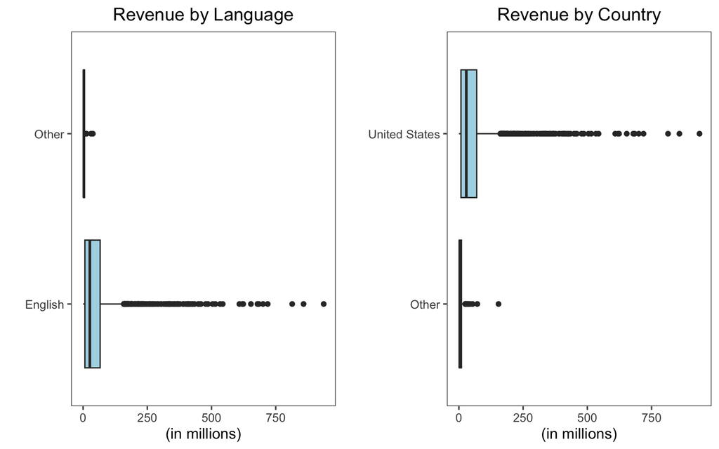

```r
p1 = ggplot(df, aes(y = ifelse(language == "English", "English", "Other"),
                    x = boxoffice*0.000001)) +
  geom_boxplot(fill = "lightblue") +
  labs(x = "(in millions)",
       y = "",
       title = "Revenue by Language") +
  theme_few() +
  theme(plot.title = element_text(hjust = 0.5))

p2 = ggplot(df, aes(y = ifelse(country == "United States", "United States", "Other"),
                    x = boxoffice*0.000001)) +
  geom_boxplot(fill = "lightblue") +
  labs(x = "(in millions)",
       y = "",
       title = "Revenue by Country") +
  theme_few() +
  theme(plot.title = element_text(hjust = 0.5))

ggarrange(p1, p2, ncol=2)
```

```r
kable(sort(round(prop.table(table(df$num_actors)),3), decreasing=TRUE), col.names=NULL) |>
  kable_styling()
```

| 3 | 0.995 |
| --- | --- |
| 1 | 0.003 |
| 0 | 0.001 |
| 2 | 0.001 |

```r
kable(sort(round(prop.table(table(df$num_directors)),3), decreasing=TRUE), col.names=NULL) |>
  kable_styling()
```

| 1 | 0.898 |
| --- | --- |
| 2 | 0.092 |
| 3 | 0.010 |

Looking at distribution of the `genre` variable,

```r
df$genre |>
  table() |>
  prop.table() |>
  sort(decreasing = TRUE) |>
  kable(col.names = NULL) |>
  kable_styling()
```

| Action | 0.2729384 |
| --- | --- |
| Comedy | 0.1945412 |
| Drama | 0.1614402 |
| Biography | 0.0952381 |
| Animation | 0.0836237 |
| Adventure | 0.0516841 |
| Horror | 0.0493612 |
| Crime | 0.0412311 |
| Documentary | 0.0389082 |
| Fantasy | 0.0040650 |
| Thriller | 0.0029036 |
| Mystery | 0.0017422 |
| Family | 0.0005807 |
| History | 0.0005807 |
| Music | 0.0005807 |
| Musical | 0.0005807 |
| Romance | 0.0000000 |
| Sci-Fi | 0.0000000 |
| Short | 0.0000000 |
| Talk-Show | 0.0000000 |

```r
df |>
  mutate(genre = as.character(genre)) |>
  mutate(genre = ifelse(genre %in% c("Action","Comedy","Drama"), genre, "Other")) |>
  select(genre) |>
  table() |>
  prop.table() |>
  kable(col.names = NULL) |>
  kable_styling()
```

| Action | 0.2729384 |
| --- | --- |
| Comedy | 0.1945412 |
| Drama | 0.1614402 |
| Other | 0.3710801 |

We take all genres that represent less than 1% of films and combine them into the category “Other”,

```r
other_genres <- df |>
  count(genre) |>
  mutate(pct = n/sum(n)) |>
  filter(pct < 0.01) |>
  pull(genre)

df <- df |>
  mutate(genre = fct_collapse(genre, Other = other_genres),
         genre = droplevels(genre))
```

Let’s take a look at the distribution of the numeric variables,

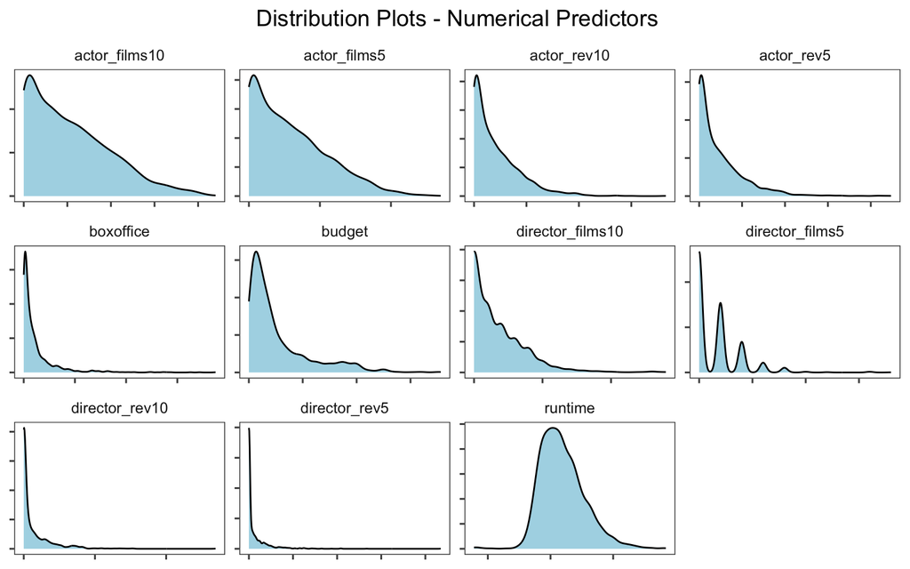

```r
df |>
  keep(is.numeric) |>
  gather() |>
  ggplot(aes(x = value)) +
  geom_density(fill="lightblue") +
  labs(title = "Distribution Plots - Numerical Predictors") +
  facet_wrap(~ key, scales = "free") +
  theme_few() +
  theme(axis.text.x = element_blank(),
        axis.text.y = element_blank(),
        axis.title.x = element_blank(),
        axis.title.y = element_blank(),
        plot.title = element_text(hjust = 0.5))
```

We can see that all of the numerical predictors are highly skewed - the `runtime` variable is the only one that is nearly normal in its distribution, though it is still right-skewed.

Now let’s take a look at the relationship between the numerical predictors and the response variable (`boxoffice`):

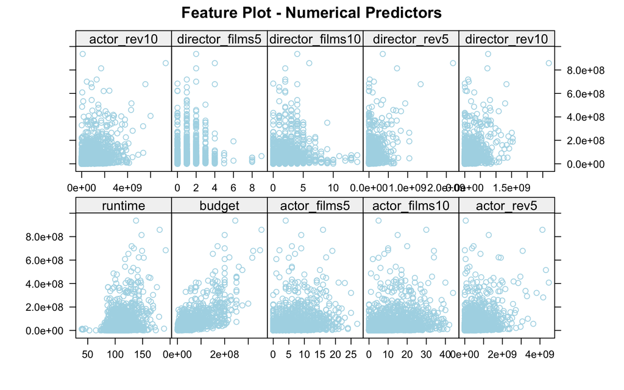

```r
featurePlot(x = select(df, where(is.numeric), -boxoffice),
            y = df$boxoffice,
            plot = "scatter",
            jitter = TRUE,
            labels = c("",""),
            col = "lightblue",
            main = "Feature Plot - Numerical Predictors")
```

Some of the models we are using do not handle missing data well. So we create a categorical variable for the missing budget data to denote if the budget data is provided or not.

```r
df <- df |>
  mutate(bud_avail = as.factor(ifelse(is.na(budget), "No", "Yes")))
```

# Modeling

Modeling for this report continues [here](https://rpubs.com/josh1den/capstone_modeling).